# Supervised machine learning

Pablo Barbera

March 6, 2017

### Supervised machine learning

We’ll be working again with tweets about the 2014 EP elections in the UK. Now we will be using the `polite` variable, which indicates whether each tweet was hand-coded as being **polite** (a tweet that adheres to politeness standards, i.e. it is written in a well-mannered and non-offensive way) or **impolite** (an ill-mannered, disrespectful tweet that may contain offensive language).

The source of the dataset is an article co-authored with Yannis Theocharis, Zoltan Fazekas, and Sebastian Popa, published in the Journal of Communication. The link is [here](http://onlinelibrary.wiley.com/doi/10.1111/jcom.12259/abstract). Our goal was to understand to what extent candidates are not engaging voters on Twitter because they’re exposed to mostly impolite messages.

Let’s start by reading the dataset and creating a dummy variable indicating whether each tweet is impolite.

```r
library(quanteda)
tweets <- read.csv("data/EP-elections-tweets.csv", stringsAsFactors=F)
tweets$impolite <- ifelse(tweets$polite=="polite", 0, 1)
```

We’ll do some cleaning as well – substituting handles with @. Why? We want to provent overfitting.

```r
tweets$text <- gsub('@[0-9_A-Za-z]+', '@', tweets$text)
```

Create the dfm and trim it so that only tokens that appear in 2 or more tweets are included.

```r
twcorpus <- corpus(tweets$text)
twdfm <- dfm(twcorpus, removePunct=TRUE, remove=c(
  stopwords("english"), "t.co", "https", "rt", "amp", "http", "t.c", "can"))
twdfm <- dfm_trim(twdfm, min_docfreq = 2)
```

And split the dataset into training and test set. We’ll go with 80% training and 20% set. Note the use of a random seed to make sure our results are replicable.

```r
set.seed(123)
training <- sample(1:nrow(tweets), floor(.80 * nrow(tweets)))
test <- (1:nrow(tweets))[1:nrow(tweets) %in% training == FALSE]
```

Our first step is to train the classifier using cross-validation. There are many packages in R to run machine learning models. For regularized regression, glmnet is in my opinion the best. It’s much faster than caret or mlr (in my experience at least), and it has cross-validation already built-in, so we don’t need to code it from scratch.

```r
library(glmnet)
require(doMC)
```

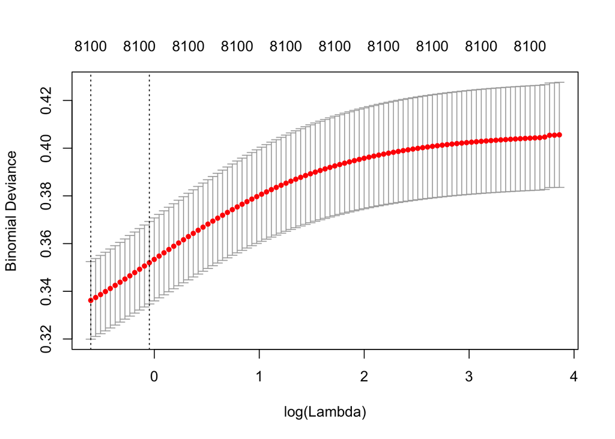

```r
registerDoMC(cores=3)
ridge <- cv.glmnet(twdfm[training,], tweets$impolite[training],
    family="binomial", alpha=0, nfolds=5, parallel=TRUE,
    type.measure="deviance")
plot(ridge)
```

We can now compute the performance metrics on the test set.

```r
## function to compute accuracy
accuracy <- function(ypred, y){
    tab <- table(ypred, y)
    return(sum(diag(tab))/sum(tab))
}
# function to compute precision
precision <- function(ypred, y){
    tab <- table(ypred, y)
    return((tab[2,2])/(tab[2,1]+tab[2,2]))
}
# function to compute recall
recall <- function(ypred, y){
    tab <- table(ypred, y)
    return(tab[2,2]/(tab[1,2]+tab[2,2]))
}
# computing predicted values
preds <- predict(ridge, twdfm[test,], type="response") > mean(tweets$impolite[test])
# confusion matrix
table(preds, tweets$impolite[test])
```

```
##
## preds      0    1
##   FALSE 1594   24
##   TRUE   308   74
```

```r
# performance metrics
accuracy(preds, tweets$impolite[test])
```

```
## [1] 0.834
```

```r
precision(preds, tweets$impolite[test])
```

```
## [1] 0.1937173
```

```r
recall(preds, tweets$impolite[test])
```

```
## [1] 0.755102
```

Something that is often very useful is to look at the actual estimated coefficients and see which of these have the highest or lowest values:

```r
# from the different values of lambda, let's pick the best one
best.lambda <- which(ridge$lambda==ridge$lambda.min)
beta <- ridge$glmnet.fit$beta[,best.lambda]
head(beta)
```

```
##            @         ukip       thanks         will           eu
##  0.004776594  0.002010902 -0.057037378 -0.039827046 -0.041486256
##         vote
## -0.004980578
```

```r
## identifying predictive features
df <- data.frame(coef = as.numeric(beta),
                word = names(beta), stringsAsFactors=F)

df <- df[order(df$coef),]
head(df[,c("coef", "word")], n=30)
```

```
##            coef           word
## 5513 -0.2191140         haaaaa
## 5093 -0.1779783     agg0ib2pgc
## 5094 -0.1779740          bantz
## 5327 -0.1582600     yugjvg8lvm
## 5834 -0.1466363           bald
## 5836 -0.1466362        villain
## 5835 -0.1466348        cockney
## 7201 -0.1453191      responses
## 2151 -0.1445876       somebody
## 5090 -0.1436079       sherlock
## 4484 -0.1401164            giv
## 7935 -0.1400730      corollary
## 7936 -0.1400711     cl9my4ob75
## 6382 -0.1375569 #leftiesinfear
```

[output cut: 16 more lines]

```r
paste(df$word[1:30], collapse=", ")
```

```
## [1] "haaaaa, agg0ib2pgc, bantz, yugjvg8lvm, bald, villain, cockney, responses, somebody, sherlock, giv, corollary, cl9my4ob75, #leftiesinfear, unnoticed, t4qlnqsllv, kippers, sheep, cry, makers, whose, password, billy's, apace, tweeted, jokes, #ukitty, hacking, weed, yea"
```

```r
df <- df[order(df$coef, decreasing=TRUE),]
head(df[,c("coef", "word")], n=30)
```

```
##          coef          word
## 3512 1.510914         nigga
## 4628 1.499940        warner
## 6354 1.491278         shush
## 6839 1.490139          sham
## 6917 1.472225        rumour
## 3612 1.468657          scum
## 4394 1.443758         steps
## 4359 1.439739        ripped
## 7015 1.386550          fits
## 7792 1.372482      #fuckoff
## 5381 1.366900     #nigelpls
## 6424 1.348299 maryhoneyball
## 1482 1.341700        wanker
## 7918 1.327761          sieg
```

[output cut: 16 more lines]

```r
paste(df$word[1:30], collapse=", ")
```

```
## [1] "nigga, warner, shush, sham, rumour, scum, steps, ripped, fits, #fuckoff, #nigelpls, maryhoneyball, wanker, sieg, cunt, mein, fuckers, cunts, messy, carperbagger, man's, hitler, 1814, mothers, dicks, slipping, cock, #mug, unlucky, scunthorpe"
```

### A special case: wordscores

Let’s check an example of wordscores. Here we have tweets from a random sample of 100 Members of the U.S. Congress, as well as their ideal points based on roll-call votes. Can we replicate the ideal points only using the text of their tweets?

```r
cong <- read.csv("data/congress-tweets.csv", stringsAsFactors=F)
# creating the corpus and dfm objects
ccorpus <- corpus(cong$text)
docnames(ccorpus) <- cong$screen_name
cdfm <- dfm(ccorpus, removePunct=TRUE, remove=c(stopwords("english"), "t.co", "https", "rt", "amp", "http", "t.c", "can"))
cdfm <- dfm_trim(cdfm, min_docfreq = 2)
# running wordscores
ws <- textmodel(cdfm, cong$idealPoint, model="wordscores", smooth=.5)
ws
```

```
## Fitted wordscores model:
## Call:
##  textmodel_wordscores(data = x, scores = y, smooth = 0.5)
##
## Reference documents and reference scores:
##
##        Documents Ref scores
##      usreprodney       0.52
##      reprichmond      -0.78
##      rephanabusa      -0.98
##  repstevestivers       0.64
##   chrisvanhollen      -1.15
##  marshablackburn       1.21
##     repjohnlewis      -1.54
##      repstutzman       1.14
##      replipinski      -0.49
##   jacksonleetx18      -1.01
##        repveasey      -0.92
##   senatorisakson       0.90
##      repmurphyfl      -0.41
##      replankford       1.01
##  juliabrownley26      -0.77
##   repterrisewell      -0.74
##    repsusandavis      -1.14
##   senatorbaldwin      -1.29
##   reploisfrankel      -1.16
##    repmarktakano      -1.24
##  repjohnsarbanes      -1.49
##  vancemcallister       1.03
##     reptimmurphy       0.84
##    senatorwicker       0.89
##     repgwenmoore      -1.32
##  gracenapolitano      -1.35
##     senatorleahy      -1.01
##       senmikelee       1.48
##  repdonnaedwards      -1.70
##      repcummings      -1.40
##        sentoomey       1.07
##  replindasanchez      -1.63
##  repmickmulvaney       1.00
```

[output cut: 65 more lines]

```
##    senatorharkin      -0.80
##  repandyharrismd       1.10
##
## Word scores: showing first 30 scored features
##
##     today      will         w     house     great      bill    thanks
##    -0.105    -0.037    -0.308     0.063    -0.112    -0.074    -0.052
##       act       new       now    bit.ly       day        us      jobs
##    -0.219    -0.159    -0.181     0.188    -0.162    -0.264    -0.098
##      work    health      time         2   support     watch      live
##    -0.368    -0.195    -0.227    -0.341    -0.258     0.052     0.136
##    senate      just      need     thank  congress      help    budget
##     0.023     0.035    -0.319    -0.196    -0.209    -0.286     0.289
## president      vote
##     0.148    -0.238
```

```r
# let's look at the most discriminant words
sw <- sort(ws@Sw)
head(sw, n=20)
```

```
##              #wi    @repmarkpocan @replindasanchez              #p2
##       -1.3336982       -1.2676828       -1.2542560       -1.2070075
##  @usprogressives    @repgwenmoore     @repcummings  @repjohnconyers
##       -1.1727257       -1.1138615       -1.1095584       -1.1079423
##   @oversightdems    #raisethewage         #renewui               tb
##       -1.0948091       -1.0942973       -1.0780929       -1.0774032
##   #climatechange     #gopshutdown @repdonnaedwards    @repjohnlewis
##       -1.0456778       -1.0423121       -1.0419288       -1.0241604
##   @repcartwright   @senatorcardin   @waysmeanscmte    #actonclimate
##       -1.0241576       -1.0089074       -0.9947521       -0.9942609
```

```r
tail(sw, n=20)
```

```
##         #pjnet     #obamacare @gopconference          is.gd          ow.ly
##      0.6778912      0.6856093      0.6856630      0.6876761      0.6942625
##          #az05   @edworkforce  @gopoversight      obamacare          #utah
##      0.7025263      0.7043443      0.7068120      0.7129859      0.7422588
##           #ar2    @toddrokita #cutcapbalance      #sctweets      @repdavid
##      0.7446765      0.7696315      0.7707696      0.7790453      0.8253965
##          #tcot    @senmikelee         #4jobs         #utsen         #utpol
##      0.8358206      0.8608569      0.8776018      0.9462197      1.0910768
```

Now let’s split the data into training and test set and see what we can learn…

```r
set.seed(123)
test <- sample(1:nrow(cong), floor(.20 * nrow(cong)))
# extracting ideal points and replacing them with missing values
refpoints <- cong$idealPoint
refpoints[test] <- NA
# running wordscores
ws <- textmodel(cdfm, refpoints, model="wordscores", smooth=.5)
# predicted values (this will take a while...)
preds <- predict(ws, rescaling="lbg")
```

```
## 34691 of 34691 features (100%) can be scored
```

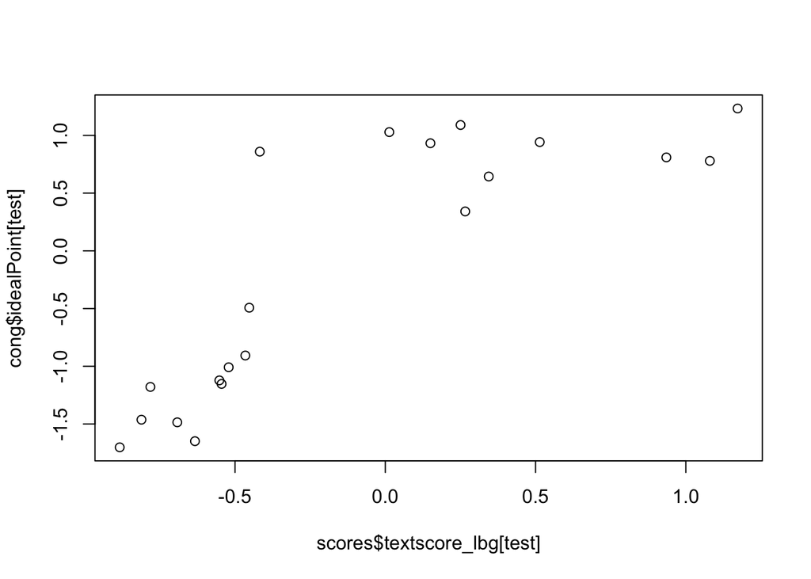

```r
scores <- preds@textscores
# and let's compare
plot(scores$textscore_lbg[test], cong$idealPoint[test])
```

```r
cor(scores$textscore_lbg[test], cong$idealPoint[test])
```

```
## [1] 0.8430282
```

### Another example: predicting authorship of tweets

Now let’s work with a dataset that contains all the tweets sent by Donald Trump, Ted Cruz, Hillary Clinton, and Bernie Sanders during the 2016 primary election campaign. Let’s pick Donald Trump and try to build a classifier to predict whether a tweet was published by him (from an Android device) or his campaign team (from an iPhone).

```r
tweets <- read.csv('data/candidate-tweets.csv', stringsAsFactors=F)
tweets <- tweets[tweets$screen_name=="realDonaldTrump",]
# subsetting tweets in 2016
tweets$datetime <- as.POSIXct(tweets$datetime)
tweets <- tweets[tweets$datetime > as.POSIXct("2016-01-01 00:00:00"),]
# variable measuring if tweet is coming from an Android device
tweets$android <- ifelse(grepl("Android", tweets$source), 1, 0)
prop.table(table(tweets$android))
```

```
##
##         0         1
## 0.4975705 0.5024295
```

```r
# removing URLs and handles
tweets$text <- gsub('https?://t.co/[A-Za-z0-9]+', '', tweets$text)
tweets$text <- gsub('@[0-9_A-Za-z]+', '@', tweets$text)
```

Create a training and test set, with 80% and 20%, respectively.

```r
set.seed(123)
training <- sample(1:nrow(tweets), floor(.80 * nrow(tweets)))
test <- (1:nrow(tweets))[1:nrow(tweets) %in% training == FALSE]
```

Construct the DFM. You may want to experiment with different preprocessing techniques until you achieve better performance.

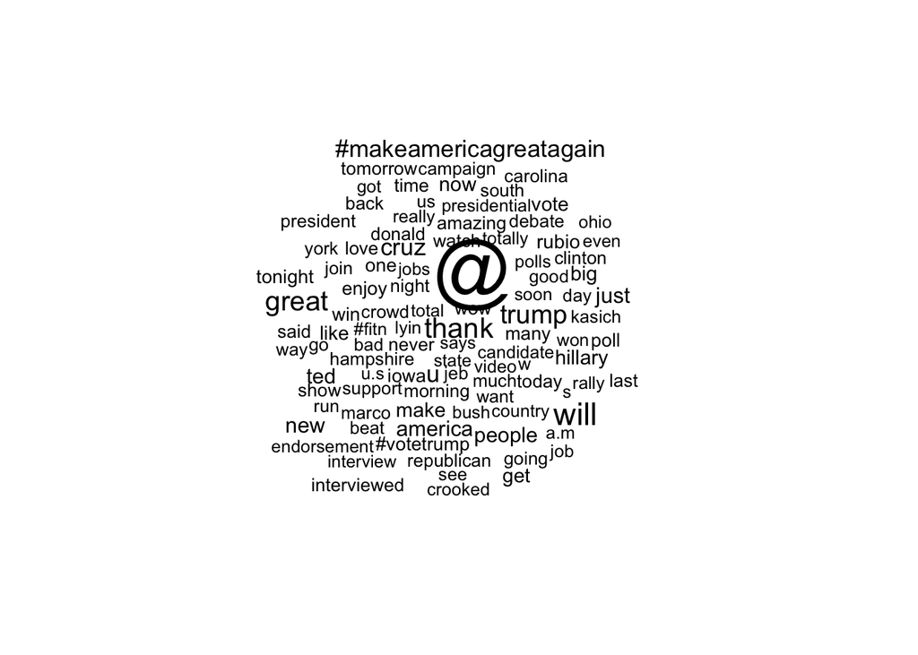

```r
library(quanteda)
twcorpus <- corpus(tweets$text)
twdfm <- dfm(twcorpus, removePunct=TRUE, removeNumbers=TRUE, remove=c(
  stopwords("english"), "t.co", "https", "rt", "amp", "http", "t.c", "can"))
#twdfm <- dfm_trim(twdfm, min_docfreq = 2)
textplot_wordcloud(twdfm, rot.per=0, scale=c(3.5, .75), max.words=100)
```

Now run the classifier. Then, compute the accuracy.

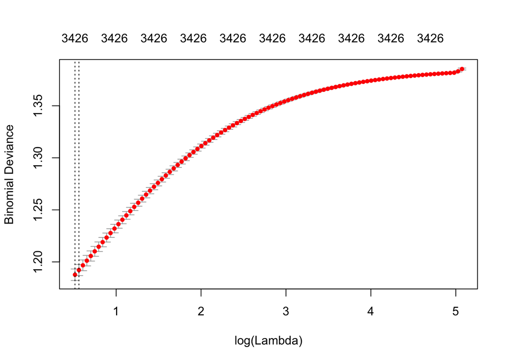

```r
library(glmnet)
require(doMC)
registerDoMC(cores=3)
ridge <- cv.glmnet(twdfm[training,], tweets$android[training],
    family="binomial", alpha=0, nfolds=5, parallel=TRUE,
    type.measure="deviance")
plot(ridge)
```

```r
## function to compute accuracy
accuracy <- function(ypred, y){
    tab <- table(ypred, y)
    return(sum(diag(tab))/sum(tab))
}
# function to compute precision
precision <- function(ypred, y){
    tab <- table(ypred, y)
    return((tab[2,2])/(tab[2,1]+tab[2,2]))
}
# function to compute recall
recall <- function(ypred, y){
    tab <- table(ypred, y)
    return(tab[2,2]/(tab[1,2]+tab[2,2]))
}
# computing predicted values
preds <- predict(ridge, twdfm[test,], type="response") > mean(tweets$android[test])
# confusion matrix
table(preds, tweets$android[test])
```

```
##
## preds     0   1
##   FALSE 146  32
##   TRUE   67 167
```

```r
# performance metrics
accuracy(preds, tweets$android[test])
```

```
## [1] 0.7597087
```

```r
precision(preds, tweets$android[test])
```

```
## [1] 0.7136752
```

```r
recall(preds, tweets$android[test])
```

```
## [1] 0.839196
```

Identify the features that better predict that tweets were sent by this candidate. What do you learn?

```r
# from the different values of lambda, let's pick the best one
best.lambda <- which(ridge$lambda==ridge$lambda.min)
beta <- ridge$glmnet.fit$beta[,best.lambda]
head(beta)
```

```
##     believe       state  department         new      year's         eve
##  0.10328729  0.07535672  0.18765888 -0.06449039  0.18766978  0.07022070
```

```r
## identifying predictive features
df <- data.frame(coef = as.numeric(beta),
                word = names(beta), stringsAsFactors=F)

df <- df[order(df$coef),]
head(df[,c("coef", "word")], n=30)
```

```
##            coef        word
## 1355 -0.2975017    powerful
## 397  -0.2961820        cams
## 2976 -0.2921037     devotes
## 1732 -0.2907008      barely
## 1904 -0.2905293 #commoncore
## 2092 -0.2902090        150m
## 3133 -0.2860437     develop
## 1261 -0.2856893   listeners
## 3611 -0.2855483      fading
## 3612 -0.2855468   guarantee
## 2846 -0.2828574   disrupted
## 3622 -0.2824625  completely
## 3400 -0.2780395   scratched
## 2168 -0.2756865  mouthpiece
```

[output cut: 16 more lines]

```r
paste(df$word[1:30], collapse=", ")
```

```
## [1] "powerful, cams, devotes, barely, #commoncore, 150m, develop, listeners, fading, guarantee, disrupted, completely, scratched, mouthpiece, cheater, insurance, trough, particular, cred, ultimate, hour, mostly, 9am, beaten, dealings, owe, clubs, pacs, dry, disarray"
```

```r
df <- df[order(df$coef, decreasing=TRUE),]
head(df[,c("coef", "word")], n=30)
```

```
##           coef                  word
## 2108 0.3097093               forties
## 2840 0.2879374                dayton
## 3542 0.2845091                mother
## 2098 0.2810814               crushed
## 3517 0.2808370             highlight
## 1317 0.2780383          introduction
## 3397 0.2759513              listened
## 307  0.2739824                #iowan
## 3063 0.2734340               corrupt
## 1965 0.2691618             hesitates
## 2463 0.2681963                  plus
## 3376 0.2678007             rochester
## 1842 0.2677947              #hannity
## 1860 0.2675883                   led
```

[output cut: 16 more lines]

```r
paste(df$word[1:30], collapse=", ")
```

[output not shown]

Trying a different classifier: Gradient Boosting of Decision Trees

```r
library(xgboost)
# converting matrix object
X <- as(twdfm, "dgCMatrix")
# running xgboost model
tryEta <- c(1,2)
tryDepths <- c(1,2,4)
bestEta=NA
bestDepth=NA
bestAcc=0

for(eta in tryEta){
  for(dp in tryDepths){
    bst <- xgb.cv(data = X[training,],
            label =  tweets$android[training],
            max.depth = dp,
          eta = eta,
          nthread = 4,
          nround = 500,
          nfold=5,
          print.every.n = 100L,
          objective = "binary:logistic")
    # cross-validated accuracy
    acc <- 1-tail(bst$test.error.mean,1)
        cat("Results for eta=",eta," and depth=", dp, " : ",
                acc," accuracy.\n",sep="")
        if(acc>bestAcc){
                bestEta=eta
                bestAcc=acc
                bestDepth=dp
        }
    }
}
```

```
## Results for eta=1 and depth=1 : 0.756384 accuracy.
## Results for eta=1 and depth=2 : 0.756382 accuracy.
## Results for eta=1 and depth=4 : 0.75031 accuracy.
## Results for eta=2 and depth=1 : 0.540144 accuracy.
## Results for eta=2 and depth=2 : 0.545508 accuracy.
## Results for eta=2 and depth=4 : 0.545479 accuracy.
```

```r
cat("Best model has eta=",bestEta," and depth=", bestDepth, " : ",
    bestAcc," accuracy.\n",sep="")
```

```
## Best model has eta=1 and depth=1 : 0.756384 accuracy.
```

```r
# running best model
rf <- xgboost(data = X[training,],
    label = tweets$android[training],
        max.depth = bestDepth,
    eta = bestEta,
    nthread = 4,
    nround = 1000,
    print.every.n = 100L,
    objective = "binary:logistic")
# out-of-sample accuracy
preds <- predict(rf, X[test,])
cat("\nAccuracy on test set=", round(accuracy(preds>.50, tweets$android[test]),3))
```

```
##
## Accuracy on test set= 0.762
```

```r
cat("\nPrecision on test set=", round(precision(preds>.50, tweets$android[test]),3))
```

```
##
## Precision on test set= 0.742
```

```r
cat("\nRecall on test set=", round(recall(preds>.50, tweets$android[test]),3))
```

```
##
## Recall on test set= 0.779
```

```r
# feature importance
labels <- dimnames(X)[[2]]
importance <- xgb.importance(labels, model = rf, data=X, label=tweets$android)
importance <- importance[order(importance$Gain, decreasing=TRUE),]
head(importance, n=20)
```

```
##                    Feature        Split        Gain       Cover Frequence
##  1:                  thank          1.5 0.129865913 0.002055375     0.001
##  2:                      @          1.5 0.110402494 0.001901155     0.001
##  3:                      u           20 0.055230523 0.003548512     0.003
##  4: #makeamericagreatagain -1.00136e-05 0.049453433 0.002764143     0.002
##  5:                   join -1.00136e-05 0.028273112 0.003853072     0.003
##  6:                      @          6.5 0.019938579 0.010784452     0.010
##  7:                      w      4.00001 0.016063013 0.001552210     0.001
##  8:                    win      4.00001 0.015725792 0.003515996     0.003
##  9:                   cruz      6.00001 0.015213563 0.001573583     0.001
## 10:                    big      6.00001 0.012928915 0.006366064     0.006
## 11:                    a.m -1.00136e-05 0.012614598 0.003944298     0.003
## 12:                   much          1.5 0.011414584 0.009953151     0.010
## 13:                  video          1.5 0.011413266 0.004681096     0.004
## 14:                    wow -1.00136e-05 0.011364231 0.006400659     0.006
```

[output cut: 27 more lines]

```r
# adding sign
sums <- list()
for (v in 0:1){
    sums[[v+1]] <- colSums(X[tweets[,"android"]==v,])
}
sums <- do.call(cbind, sums)
sign <- apply(sums, 1, which.max)

df <- data.frame(
    Feature = labels,
    sign = sign-1,
    stringsAsFactors=F)
importance <- merge(importance, df, by="Feature")

## best predictors
for (v in 0:1){
    cat("\n\n")
    cat("value==", v)
    importance <- importance[order(importance$Gain, decreasing=TRUE),]
    print(head(importance[importance$sign==v,], n=50))
    cat("\n")
    cat(paste(unique(head(importance$Feature[importance$sign==v], n=50)), collapse=", "))
}
```

```
##
##
## value== 0                   Feature        Split        Gain       Cover Frequence
##  1:                  thank          1.5 0.129865913 0.002055375     0.001
##  2:                      u           20 0.055230523 0.003548512     0.003
##  3: #makeamericagreatagain -1.00136e-05 0.049453433 0.002764143     0.002
##  4:                   join -1.00136e-05 0.028273112 0.003853072     0.003
##  5:                      w      4.00001 0.016063013 0.001552210     0.001
##  6:                  video          1.5 0.011413266 0.004681096     0.004
##  7:                    via -1.00136e-05 0.009641320 0.002706817     0.002
##  8:             #votetrump -1.00136e-05 0.007410575 0.002410718     0.002
##  9:               tomorrow -1.00136e-05 0.006841315 0.006159178     0.006
## 10:           pennsylvania -1.00136e-05 0.005966544 0.002581766     0.002
## 11:                      t      4.00001 0.005868505 0.005478357     0.005
## 12:                  #fitn -1.00136e-05 0.005755669 0.002505325     0.002
```

[output cut: 200 more lines]